# Chapter5 Statistics-Hypothesis Testing : Ravi Mummigatti : 26-12-20

## Testing for an association between two variables at the population level

When we have a sample of data with two variables, and want to know if there is an association between those variables at the population level, we’ll need a different set of hypothesis tests. For example, we might be interested in the relationship between:

- claw size and species of bear (black vs grizzly bears)
- tree height and the species of tree (for pine, oak, and spruce trees)
- subscription rates for 2 versions of a web page among all site visitors

In each of these examples, we cannot observe the entire population of interest (eg., the entire wild population of each species of bear).Instead, we can collect data for a smaller sample and then use a hypothesis test to understand the likelihood that a similar association exists among the population we care about

**Example: two-sample t-test**

A two-sample t-test is used to investigate an association between a quantitative variable and a binary categorical variable. For example, suppose we want to test if there is an association between claw size (quantitative) and species: black or grizzly bear (binary categorical). To answer this question, we could sample a selection of black bears and grizzly bears, then calculate the average claw size for each species. Then, we can use a two-sample t-test to determine the probability that the claw sizes for these two species are significantly different (among the entire population of black and grizzly bears). The data might look like this:

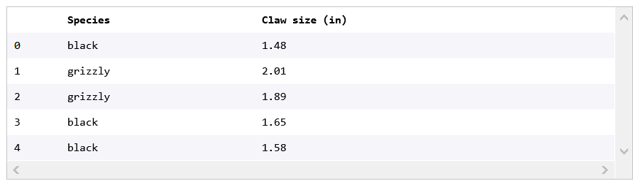

And the code to run the two-sample t-test will look like this:

.......................................................................  
from scipy.stats import ttest_ind

*separate out claw lengths for two species*  
grizzly_bear = data.claw_length[data.species=='grizzly']  
black_bear = data.claw_length[data.species=='black']

*run the t-test here*  
tstat, pval = ttest_ind(grizzly_bear, black_bear)  
.......................................................................  
Other examples of two-sample t-tests include studies like drug trials or psychology studies with a control and experimental group or A/B Testing with quantitative data like “time spent on a website”.

**Example: ANOVA and Tukey’s range test**  
In cases similar to the two-sample t-test, but when the categorical variable has three or more categories, an ANOVA can be used to see if there is a significant difference between any of the groups. Then, if at least one pair of groups are significantly different, Tukey’s range test can be used to determine which groups are different. This is better than running multiple two-sample t-tests because it leads to a lower probability of making a type I error.

For example, if we want to compare the heights of three different tree species, in order to test the hypothesis that average tree heights vary by species, we can use an ANOVA. Then, if the p-value from the ANOVA is below our significance threshold, we can run Tukey’s range test to determine which tree species have significantly different heights.

The code to run these tests is as follows:  
.......................  
*ANOVA Test*  
from scipy.stats import f_oneway  
fstat, pval = f_oneway(heights_pine, heights_oak, heights_spruce)

*Tukey’s Range Test*  
from statsmodels.stats.multicomp import pairwise_tukeyhsd  
tukey_results = pairwise_tukeyhsd(tree_data.height, tree_data.species, 0.05) .......................

**Example: Chi-Square test**  
When looking at the relationship between two categorical variables, we can run a Chi-Square Test to see if there is a significant association between the variables. Both variables can have any number of categories. Some examples include testing an association between:

- Smoking and lung cancer
- Website version and whether or not someone subscribed
- Education level and tax income bracket (multiple categories such as “under 40k”, ”40k-60k”, ”60-80k”, etc)

For example, suppose we are interested in understanding whether there is an association between the version of a website someone sees and whether or not they subscribe. The data may look something like this:

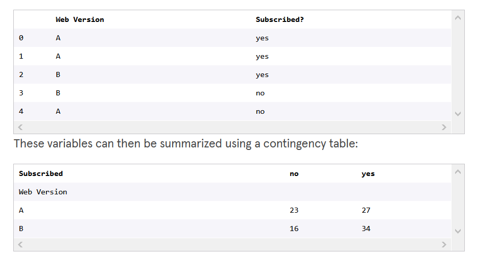

A Chi-Square test evaluates whether the observed contingency table is significantly different from the table that would be expected if there were no association between the variables. The code to create the contingency table and run the Chi-Square test looks something like this:  
................................  
import pandas as pd  
from scipy.stats import chi2_contingency

*create contingency table*  
ab_contingency = pd.crosstab(data.Web_Version, data.Subscribed)

*run a Chi-Square test*  
chi2, pval, dof, expected = chi2_contingency(ab_contingency)  
.................................